# IODS course project

Ilse Ekman

# About the project

This is the start! I am excited to learn some **serious** R coding skills!

## Link to my GitHub repository:

https://github.com/ilseek/IODS-project

# Excercise **2**

*Description of my work this week:*

In the second exercise we practise data wrangling and regression analysis.

In the data wrangling part we first read the text file into a data.frame:

lrn14 <- read.table(“http://www.helsinki.fi/~kvehkala/JYTmooc/JYTOPKYS3-data.txt”, sep=", header=TRUE)

dim(lrn14) str(lrn14) The commands dim() and str()are good to figure out how your data looks like. **Dim()** gives you the number of rows and columns in your data. In this case 183 rows or cases and 60 columns or variables. **Str()** returns the structure of data more in detail.Besides the number of observations and variables,it tells name of the vectors and data type.

*The data needs to be cleaned:*

deep_questions <- c(“D03”, “D11”, “D19”, “D27”, “D07”, “D14”, “D22”, “D30”,“D06”, “D15”, “D23”, “D31”) surface_questions <- c(“SU02”,“SU10”,“SU18”,“SU26”, “SU05”,“SU13”,“SU21”,“SU29”,“SU08”,“SU16”,“SU24”,“SU32”) strategic_questions <- c(“ST01”,“ST09”,“ST17”,“ST25”,“ST04”,“ST12”,“ST20”,“ST28”) attitude_questions <- c(“Da”, “Db”, “Dc”, “Dd”, “De”, “Df”, “Dg”, “Dh”, “Di”,“Dj”)

After installing dplyr package it is called: library(dplyr)

Now **select()** can be used: deep_columns <- select(lrn14, one_of(deep_questions)) surface_columns <- select(lrn14, one_of(surface_questions)) strategic_columns <- select(lrn14, one_of(strategic_questions))

To scale down the combination variables you can take the mean: lrn14$deep <- rowMeans(deep_columns) lrn14$surf <- rowMeans(surface_columns) lrn14$stra <- rowMeans(strategic_columns)

keep_columns <- c(“gender”,“Age”,“Attitude”, “deep”, “stra”, “surf”, “Points”)

learning2014 <- select(lrn14, one_of(keep_columns))

Scale down the Attitude: learning2014$Attitude <- c(learning2014$Attitude) / 10 learning2014$Attitude

With **filter()** you can exclude observations with 0 points: learning2014 <- filter(learning2014, Points > 0)

I checked that the dimensions of the data are as told: dim(learning2014)

The created data file is set as a working directory: setwd(“~/IODS-project”)

And saved as a csv file: write.csv(learning2014,file = “learning2014.csv”)

To read the file you can use command: read.csv(“learning2014.csv”)

## Analysis of the data

read.csv(“learning2014.csv”)

dim(learning2014) str(learning2014)

This dataset has 166 observations with seven variables. The different variables are: gender which is factor with two levels. Attitude,deep, stra and surf are numeric variables.

## Graphical overview of the data

pairs(learning2014[-1], col = learning2014$gender)

Correcting the names of the columns: colnames(learning2014)[7] <- “points” colnames(learning2014)[2] <- “age” colnames(learning2014)[3] <- “attitude”

pairs(learning2014[-1], col = learning2014$gender)

library(GGally)

p <- ggpairs(learning2014, mapping = aes(col = gender, alpha = 0.3), lower = list(combo = wrap(“facethist”, bins = 20))) p

library(ggplot2)

p1 <- ggplot(learning2014, aes(x = attitude, y = points, col = gender)) p2 <- p1 + geom_point() p2 p3 <- p2 + geom_smooth(method = “lm”) p3

## Summary of the data

summary(learning2014)

## Regression model

ggpairs(learning2014, lower = list(combo = wrap(“facethist”, bins = 20))) my_model2 <- lm(points ~ attitude + stra + surf, data = learning2014)

## Diagnostic plots

# Exercise 3

## Analysis of the third exercise

```r
alc <-read.table("http://s3.amazonaws.com/assets.datacamp.com/production/course_2218/datasets/alc.txt", sep = ",", header = TRUE)
```

**Structure of the data:**

```r
str(alc)
```

```
## 'data.frame':    382 obs. of  35 variables:
##  $ school    : Factor w/ 2 levels "GP","MS": 1 1 1 1 1 1 1 1 1 1 ...
##  $ sex       : Factor w/ 2 levels "F","M": 1 1 1 1 1 2 2 1 2 2 ...
##  $ age       : int  18 17 15 15 16 16 16 17 15 15 ...
##  $ address   : Factor w/ 2 levels "R","U": 2 2 2 2 2 2 2 2 2 2 ...
##  $ famsize   : Factor w/ 2 levels "GT3","LE3": 1 1 2 1 1 2 2 1 2 1 ...
##  $ Pstatus   : Factor w/ 2 levels "A","T": 1 2 2 2 2 2 2 1 1 2 ...
##  $ Medu      : int  4 1 1 4 3 4 2 4 3 3 ...
##  $ Fedu      : int  4 1 1 2 3 3 2 4 2 4 ...
##  $ Mjob      : Factor w/ 5 levels "at_home","health",..: 1 1 1 2 3 4 3 3 4 3 ...
##  $ Fjob      : Factor w/ 5 levels "at_home","health",..: 5 3 3 4 3 3 3 5 3 3 ...
##  $ reason    : Factor w/ 4 levels "course","home",..: 1 1 3 2 2 4 2 2 2 2 ...
##  $ nursery   : Factor w/ 2 levels "no","yes": 2 1 2 2 2 2 2 2 2 2 ...
##  $ internet  : Factor w/ 2 levels "no","yes": 1 2 2 2 1 2 2 1 2 2 ...
##  $ guardian  : Factor w/ 3 levels "father","mother",..: 2 1 2 2 1 2 2 2 2 2 ...
```

[output cut: 21 more lines]

This data is a combined data from two datasets regarding the performance in mathematics and Portuguese language.

The data has 382 observations of 35 variables.

**The names of the variables:**

```r
colnames(alc)
```

```
##  [1] "school"     "sex"        "age"        "address"    "famsize"
##  [6] "Pstatus"    "Medu"       "Fedu"       "Mjob"       "Fjob"
## [11] "reason"     "nursery"    "internet"   "guardian"   "traveltime"
## [16] "studytime"  "failures"   "schoolsup"  "famsup"     "paid"
## [21] "activities" "higher"     "romantic"   "famrel"     "freetime"
## [26] "goout"      "Dalc"       "Walc"       "health"     "absences"
## [31] "G1"         "G2"         "G3"         "alc_use"    "high_use"
```

**The purpose of my analysis is to study the relationship between alcohol consumption and following four variables:**

**1.sex: I hypothesize that male students have higher consumption of alcohol.**

**2.age: I hypothesize that the older the student is the more they consume alcohol.**

**3.goout: I hypothesize that the more the student goes out with friends the bigger their alcohol consumption is.**

**4.health: I hypothesize that the current health status is worse in the students with higher alcohol consumption.**

**Exploring the first hypothesis:**

```r
library(dplyr); library(ggplot2)
alc %>% group_by(sex, high_use) %>% summarise(count = n())
```

```
## # A tibble: 4 x 3
## # Groups:   sex [2]
##   sex   high_use count
##   <fct> <lgl>    <int>
## 1 F     FALSE      157
## 2 F     TRUE        41
## 3 M     FALSE      113
## 4 M     TRUE        71
```

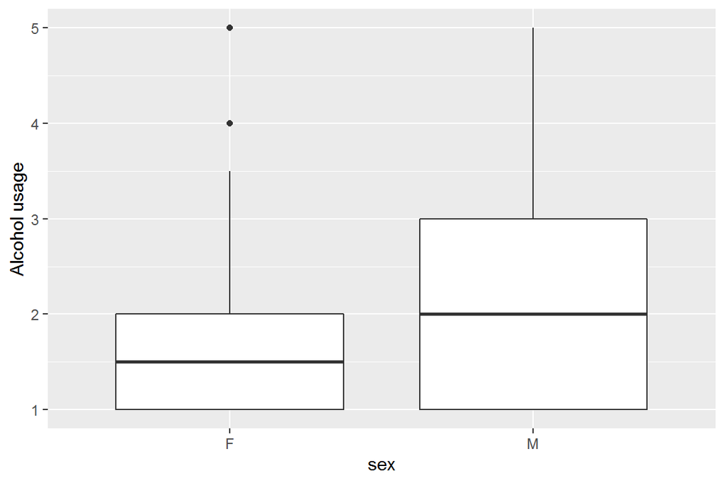

```r
g1 <- ggplot(alc, aes(x = sex, y = alc_use))
g1 + geom_boxplot() + ylab("Alcohol usage")
```

**1: It seems male students have higher consumption of alcohol.**

**Exploring the second hypothesis:**

```r
alc %>% group_by(age, high_use) %>% summarise(count = n())
```

```
## # A tibble: 12 x 3
## # Groups:   age [7]
##      age high_use count
##    <int> <lgl>    <int>
##  1    15 FALSE       63
##  2    15 TRUE        18
##  3    16 FALSE       79
##  4    16 TRUE        28
##  5    17 FALSE       65
##  6    17 TRUE        35
##  7    18 FALSE       55
##  8    18 TRUE        26
##  9    19 FALSE        7
## 10    19 TRUE         4
## 11    20 FALSE        1
## 12    22 TRUE         1
```

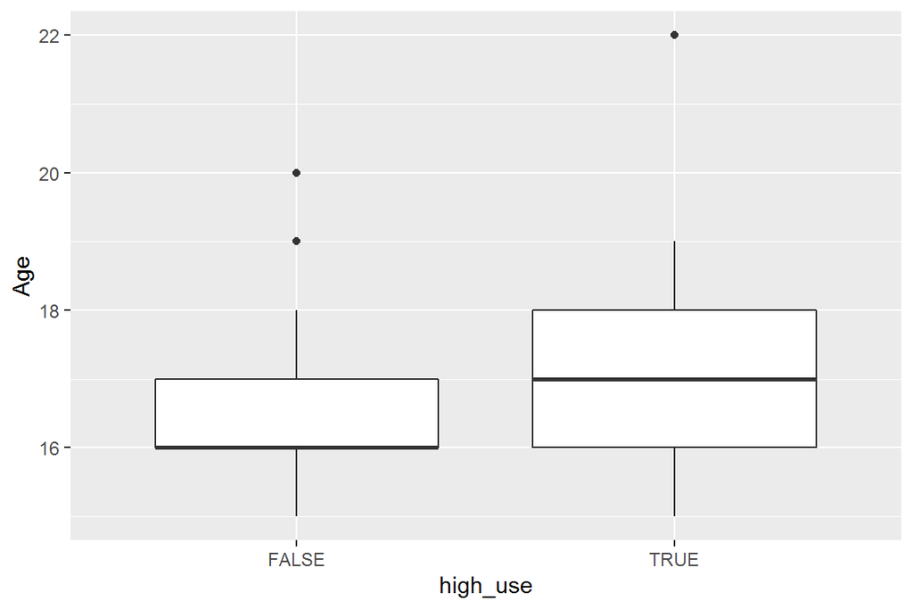

```r
g2 <- ggplot(alc, aes(x = high_use, y = age))
g2 + geom_boxplot() + ylab("Age")
```

**2: It seems older students have higher consumption of alcohol.**

**Exploring the third hypothesis:**

```r
alc %>% group_by(goout, high_use) %>% summarise(count = n())
```

```
## # A tibble: 10 x 3
## # Groups:   goout [5]
##    goout high_use count
##    <int> <lgl>    <int>
##  1     1 FALSE       21
##  2     1 TRUE         3
##  3     2 FALSE       84
##  4     2 TRUE        15
##  5     3 FALSE      100
##  6     3 TRUE        23
##  7     4 FALSE       43
##  8     4 TRUE        39
##  9     5 FALSE       22
## 10     5 TRUE        32
```

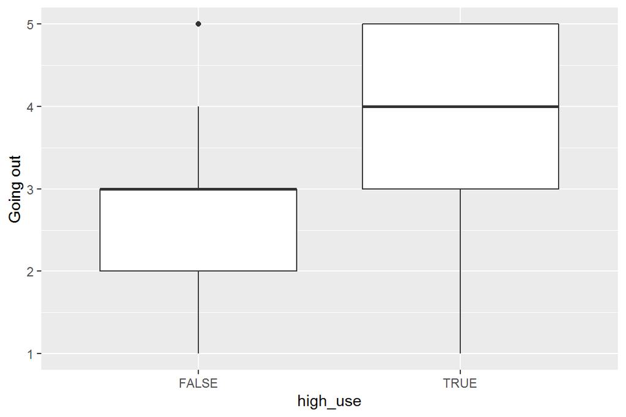

```r
g3 <- ggplot(alc, aes(x = high_use, y = goout))
g3 + geom_boxplot() + ylab("Going out")
```

**3: Going out more frequently seems to correlate to higher alcohol consumption.**

**Exploring the fourth hypothesis:**

```r
alc %>% group_by(health, high_use) %>% summarise(count = n())
```

```
## # A tibble: 10 x 3
## # Groups:   health [5]
##    health high_use count
##     <int> <lgl>    <int>
##  1      1 FALSE       35
##  2      1 TRUE        11
##  3      2 FALSE       29
##  4      2 TRUE        14
##  5      3 FALSE       63
##  6      3 TRUE        20
##  7      4 FALSE       47
##  8      4 TRUE        17
##  9      5 FALSE       96
## 10      5 TRUE        50
```

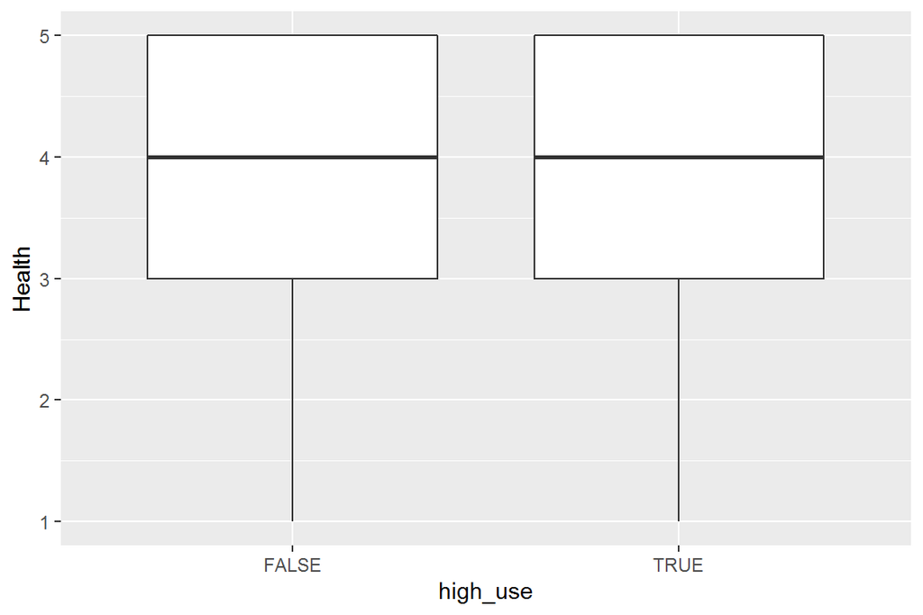

```r
g4 <- ggplot(alc, aes(x = high_use, y = health))
g4 + geom_boxplot() + ylab("Health")
```

**4: Current health status of a student does not seem to reflect the alcohol consumption.**

**Exploring the variables with logistic regression:**

```r
m <- glm(high_use ~ sex + age + goout + health, data = alc, family = "binomial")

summary(m)
```

```
##
## Call:
## glm(formula = high_use ~ sex + age + goout + health, family = "binomial",
##     data = alc)
##
## Deviance Residuals:
##     Min       1Q   Median       3Q      Max
## -1.6588  -0.8201  -0.5777   0.8775   2.5750
##
## Coefficients:
##             Estimate Std. Error z value Pr(>|z|)
## (Intercept) -6.11487    1.83697  -3.329 0.000872 ***
## sexM         0.85484    0.25138   3.401 0.000672 ***
## age          0.12110    0.10626   1.140 0.254400
## goout        0.73941    0.11854   6.238 4.44e-10 ***
## health       0.09356    0.09067   1.032 0.302106
## ---
## Signif. codes:  0 '***' 0.001 '**' 0.01 '*' 0.05 '.' 0.1 ' ' 1
##
## (Dispersion parameter for binomial family taken to be 1)
##
##     Null deviance: 462.21  on 381  degrees of freedom
## Residual deviance: 397.09  on 377  degrees of freedom
## AIC: 407.09
##
## Number of Fisher Scoring iterations: 4
```

```r
coef(m)
```

```
## (Intercept)        sexM         age       goout      health
## -6.11486907  0.85484147  0.12110491  0.73941072  0.09356162
```

**To compute out odds ratios:**

```r
OR <- coef(m) %>% exp
```

**To compute out confidence intervals:**

```r
CI <- confint(m) %>% exp
cbind(OR, CI)
```

```
##                      OR        2.5 %     97.5 %
## (Intercept) 0.002209765 5.593849e-05 0.07655548
## sexM        2.351001643 1.442941e+00 3.87351253
## age         1.128743323 9.171918e-01 1.39274305
## goout       2.094700778 1.670317e+00 2.66104027
## health      1.098078261 9.206963e-01 1.31483045
```

**To predict the probability of high alcohol usage:**

probabilities <- predict(m, type = “response”)

alc <- mutate(alc, probability = probabilities)

alc <- mutate(alc, prediction = probability > 0.5)

select(alc, failures, absences, sex, high_use, probability, prediction) %>% tail(10)

table(high_use = alc$high_use, prediction = alc$prediction)